# Hospitalizations for psychiatric conditions among adolescents during the COVID-19 pandemic

```r
# Install packages
paket <- function(pak){
  new_pak <- pak[!(pak %in% rownames(installed.packages()))]
  if (length(new_pak))
    install.packages(new_pak, dependencies = TRUE,repos="https://cloud.r-project.org/")
  sapply(pak, library, character.only = TRUE)
}

listOfPackages <- c("tidyverse", "RColorBrewer", "knitr", "kableExtra", "tsModel")
paket(listOfPackages)
```

```r
# options(repr.plot.width = 18, repr.plot.height = 9)
theme_plots <- theme_bw() +
  theme(strip.text = element_text(size = 5),
        axis.text.x = element_text(size = 8),
        axis.text.y = element_text(size = 6),
        axis.title.x = element_text(size = 8),
        axis.title.y = element_text(size = 8),
        title = element_text(size = 10),
        plot.subtitle = element_text(size = 9, face = "italic"))
theme_set(theme_plots)

# Colorblind palette
cbPalette <- c("#999999", "#E69F00", "#56B4E9", "#009E73", "#F0E442", "#0072B2", "#D55E00", "#CC79A7")
```

# Inclusion criteria

# Variables that need to be checked/modified by each site

Change the values of the following variables according to the specificities of your site: - “folder_4ce_files”: folder path where your phase 2.2 data files are located - “obfuscation”: determine the obfuscation threshold (FALSE if no obfuscation, or the numeric value of the obfuscation threshold if any) - “raceAvailable”: set as TRUE or FALSE depending on whether the variable is being collected at your site - “dateFormat”: specify the format of the date at your site (e.g., for “03-AUG-20”, the format would be “%d-%b-%y”, [see documentation](https://www.stat.berkeley.edu/~s133/dates.html))

```r
folder_4ce_files <- "/Input/09212021_2/"
obfuscation =  FALSE
#obfuscation = 3
raceAvailable = TRUE
#raceAvailable = FALSE
dateFormat <- "%d-%b-%y"
```

```r
# cut-off dates used in the analysis, these should not be changed
history_start_date <- "2019-01-01"
history_end_date <- "2021-05-31"
pandemic_start_date <- "2020-03-15"
```

# Data input

We will use as input the 2.2 data files. Specifically: - LocalPatientSummary - LocalPatientObservation - LocalPatientClinicalcourse

For sites recording the race, we will also use an additional file: - LocalPatientRace

## Read csv files

### 4CE phase 2.2 files

```r
### Read the CSV input files
source("R/readInputFiles.R")


files <- readInputFiles( path      = "../Input/09212021_2/",
                         separator = ",",
                         skip      = 0,
                         verbose   = FALSE )

## Create the output folder if it doesn't exist
#if (! "output" %in% list.dirs()) dir.create("output")

### Extract the patient summary and observation information.
demo_raw <- files[["patientSummary"]]
obs_raw <- files[["patientObservations"]]
clinical_raw <- files[["patientClinicalCourse"]]

### Read the file containing race information for those sites recording this variable
if( raceAvailable == TRUE ){
  race_raw <- read.delim(paste0("../", folder_4ce_files, "/LocalPatientRace.csv"), sep = ",", skip = 0)
}
```

```r
# Adding filtering on in_hospital == 1 here to reduce subsequent compute time
clinical_raw <- filter(clinical_raw, in_hospital == 1)
```

### Read the ICD10 codes file

The file containing the ICD10 psychiatric related codes is located in the `public-data` folder of the GitHub repository.

```r
#icdCodes <- read.csv("public-data/pediatric_psychiatric_ICD10_codes.csv", header = TRUE, colClasses = "character") %>%
#  rename(disorder_group = Mental.Health.Disorder.Group,
#         description = Description,
#         originalCode = ICD10_Code) %>%
#  mutate( ICD10_Code= ifelse( nchar( originalCode) > 3, paste0(substr( originalCode, 1, 3), ".", substr(  originalCode, 4, nchar(originalCode))),originalCode)) %>%
#  select( disorder_group, ICD10_Code, description)

icdCodes <- read.csv("public-data/pediatric_psychiatric_ICD10_codesV2.csv", header = TRUE, colClasses = "character") %>%
   filter( flag %in% c("originalCodes", "FrenchSpecificCodes")) %>%
   select( disorder_group, ICD10_Code, description )
```

# Data management

We will select only patients that have been diagnosed with at least one of the mental health ICD10 codes at any point during study followup. For these patients we will generate a table that will allow us to perform all the analysis required for this study. This transformed table will contain 9 columns: - patient_num: patient internal identifier - sex (male, female) - age (in years) - concept_type (DIAG-ICD10) - concept_code (ICD-10 full code, e.g, R44.1) - calendar_date (day-month-year, 30-SEP-20) - hospitalization status (1, 0) - n_hospitalization (the hospitalization number) - len_hospitalization (length of each hospitalization)

The last two columns are not available in the input data files. We will generate those counts using the information available in the clinical raw file.

```r
# Adjusting patient age at the time of visit, assuming the age used is the patients' age at the time of extraction (last discharge date available in the data)
last_data_date <- max(as.Date(demo_raw$last_discharge_date, "%Y-%m-%d"))
clinical_raw <- left_join(clinical_raw, demo_raw[c("patient_num", "cohort", "age")], by = c("patient_num", "cohort"))
clinical_raw$age_time_visit <- clinical_raw$age - floor(as.numeric(last_data_date - as.Date(clinical_raw$calendar_date, dateFormat)) / 365.25)
clinical_raw <- select(clinical_raw, -age)
```

## Adding columns with hospitalization number and hospitalization length to the clinical raw file

```r
count_sequences_hospitalisation <- function(df, ...) {
  seq_hospitalisation_df <- data.frame(total_span = seq(min(df$days_since_admission),
                                                        max(df$days_since_admission))
  ) %>%
    left_join(df, by = c("total_span" = "days_since_admission")) %>%
    replace_na(list(in_hospital = 0))
  count_sequences <- rle(seq_hospitalisation_df$in_hospital)
  count_sequences_1 <- lapply(count_sequences, function(x) x[count_sequences$values == 1])
  n_sequences <- seq_along(count_sequences_1$lengths)
  sequences <- rep.int(n_sequences, count_sequences_1$lengths)
  sequences_len <- rep.int(count_sequences_1$lengths, count_sequences_1$lengths)
  stopifnot(length(df$days_since_admission) == length(sequences))
  data.frame(days_since_admission = df$days_since_admission,
             n_hospitalisation = sequences,
             len_hospitalisation = sequences_len)
}
stopifnot(all(clinical_raw$in_hospital == 1))
hospitalisations_seq_df <- clinical_raw %>%
  distinct(patient_num, cohort, days_since_admission, in_hospital) %>%
  group_by(patient_num, cohort) %>%
  group_modify(count_sequences_hospitalisation)
clinical_raw <- left_join(clinical_raw,
                          hospitalisations_seq_df,
                          by = c("patient_num", "cohort", "days_since_admission"))
```

## Creating the inputTable

Creation of the inputTable that will be the only table used throughout the rest of the analysis - selecting only visits with at least one ICD codes pertaining to the mental health categories - filter visits where patients are between 11 and 17 years old - add the demographic and hospitalization related information - add the ICD code description and the related disorder group

We will also transform the observation dates, and break it by weeks, adding 2 additional columns: “weeks” and “year”. Finally, we will dichotomize the study timeframe in two periods, based on cut-off dates, “before_pandemic”, and “during_pandemic”.

Additionally, we will also add the information about race to the table for sites collecting this information.

### Check that we have patients with the ICD10 mental codes

```r
### check that the ICD codes follow the regular expression [A-Z][0-9][0-9AB]\.?[0-9A-TV-Z]{0,4}
codesToReview <- obs_raw %>% dplyr::filter(concept_type == "DIAG-ICD10",
                                           ! grepl( "[A-Z][0-9][0-9AB]\\.?[0-9A-TV-Z]{0,4}", concept_code))
print(codesToReview)
```

```
##   siteid cohort patient_num days_since_admission concept_type concept_code
## 1    BCH AllAdm     1745440                  105   DIAG-ICD10          FDX
##   value
## 1  -999
```

```r
### Calculate how many of the mental codes are in the dataset
mentalHealthCodes <- unique( obs_raw %>%
  dplyr::filter( concept_type == "DIAG-ICD10",
                 concept_code %in% icdCodes$ICD10_Code ) %>%
  dplyr::mutate( concept_code = as.character( concept_code ),
                 concept_length = nchar( concept_code ),
                 concept_check = ifelse( concept_length == 4 | concept_length > 8, "Check", "OK")) %>%
  dplyr::select( concept_code, concept_length, concept_check) )

summary(as.factor( mentalHealthCodes$concept_check ) )
```

```
##  OK
## 504
```

```r
print( paste0("There are ", length(mentalHealthCodes$concept_code), " ICD10 mental codes out of the total ",length(unique(icdCodes$ICD10_Code)), " in the dataset"))
```

```
## [1] "There are 504 ICD10 mental codes out of the total 1699 in the dataset"
```

```r
### Joining the icd code description to the table
obs_raw <- obs_raw %>%
  left_join(icdCodes, by = c("concept_code" = "ICD10_Code"))
```

### Data management for the patientClinicalCourse table

```r
clinical_raw <- clinical_raw %>%
  dplyr::mutate( date = as.Date( calendar_date, format = dateFormat ),
                 weeks = as.Date(cut( date, breaks = "week")),
                 month = as.Date(cut( date, breaks = "month")),
                 year = format( date, "%Y"),
                 period = ifelse( date < pandemic_start_date,
                                  "before_pandemic","during_pandemic")) %>%
  dplyr::filter(cohort  %in% c("AllAdm"))
```

### Generating the table

```r
# Getting site name, will be used later in the analysis
site <- unique(as.character(demo_raw$siteid))

#early_pandemic_start_date <- "2020-03-15"
#late_pandemic_start_date <- "2021-01-01"

icdCategory <- read.delim("public-data/icd10Codes.txt", header = FALSE, colClasses = "character")
colnames(icdCategory) <- c("icd_code_letter", "icd_description_category")

all_codes <- obs_raw %>%
  full_join( clinical_raw,  by = c("patient_num", "cohort", "days_since_admission")) %>%
  full_join( demo_raw, by = c("patient_num", "cohort")) %>%
  mutate(icd_code_category = ifelse(concept_code %in% icdCodes$ICD10_Code,
                               "psy",
                               "others")) %>%
  dplyr::filter( concept_type == "DIAG-ICD10",
                 in_hospital == 1,
                 age < 18 & age > 10,
                 date >= history_start_date & date <= history_end_date) %>%
  dplyr::select( patient_num, cohort, sex, age, concept_type, concept_code, calendar_date,
                 in_hospital, n_hospitalisation, len_hospitalisation, date, weeks, month, year,
                 period, disorder_group, description, icd_code_category )

all_codes <- all_codes %>%
  mutate( icd_code_letter = ifelse(substr(concept_code, 1, 1) %in% c("D", "H"), substr(concept_code, 1, 2), substr(concept_code, 1, 1) ))

all_codes <- left_join( all_codes, icdCategory) %>%
  mutate( icd_description_category = replace_na( ifelse( concept_code %in% icdCodes$ICD10_Code, "Psy", icd_description_category), "Others"))

input_data <- all_codes %>%
  filter(concept_code %in% icdCodes$ICD10_Code)

if( raceAvailable == TRUE ){
  input_data <- input_data %>%
    left_join( race_raw, by = c("patient_num", "cohort") )
}
```

# Data analysis

## Patients having presented history of mental health related issues before pandemic

We estimate the number of patients that presented a mental health disorder (grouped by mental health disorder groups - icdCodes$disorder_group): - only before the pandemic - only during the pandemic - both before and during pandemic

The output is a barplot showing in the x-axis the number of patients, and in the y-axis the distinct disorder groups. Each disorder group has 3 bars associated based on the three previous options.

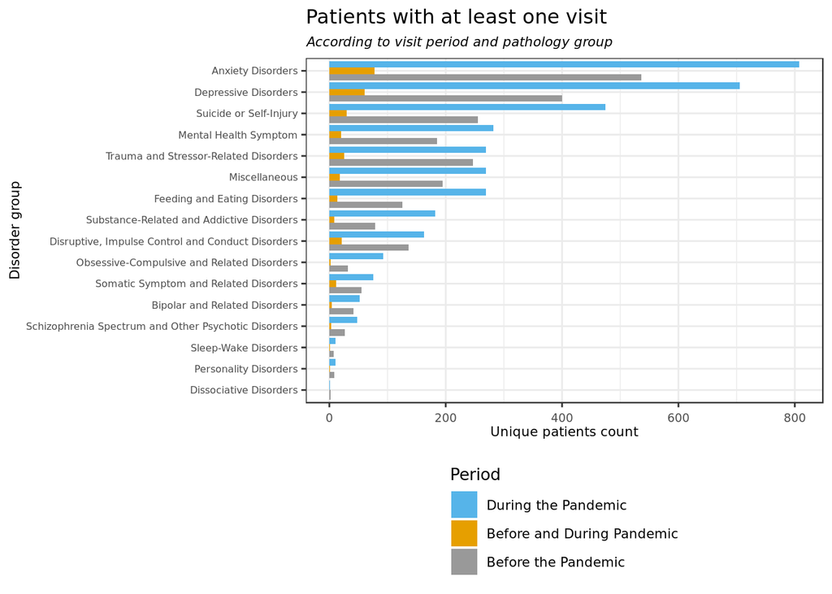

```r
patient_count_barplot_period <- input_data %>%
  dplyr::group_by( disorder_group, patient_num, cohort) %>%
  dplyr::mutate(
    when = ifelse( "before_pandemic" %in% period & "during_pandemic" %in% period,
                   "Before and During Pandemic",
                   ifelse( "before_pandemic" %in% period & ! "during_pandemic" %in% period,
                           "Before the Pandemic",
                           "During the Pandemic"
                   )
    )
    %>% factor(levels = c("Before the Pandemic", "Before and During Pandemic", "During the Pandemic"))
  ) %>%
  dplyr::ungroup() %>%
  dplyr::select( patient_num, cohort, disorder_group, when ) %>%
  dplyr::group_by( disorder_group, when ) %>%
  dplyr::summarise( count = n_distinct( patient_num, cohort ) ) %>%
  dplyr::mutate(count = ifelse(count > obfuscation | isFALSE(obfuscation),
                               count,
                               0.5),
                siteid = site)
# create a vector with the disorder groups sorted in decreasing order
order_disorders <- patient_count_barplot_period %>%
  filter( when == "During the Pandemic") %>%
  arrange( count ) %>%
  select( disorder_group )

patient_count_barplot_period$orderDisorder <- factor(patient_count_barplot_period$disorder_group,
                                                     levels = as.factor( order_disorders$disorder_group ))

patient_count_barplot_period %>%
  ggplot(aes(x = as.factor( orderDisorder), y = count, fill = when)) +
  geom_bar(stat="identity", position = "dodge") +
  scale_fill_manual(values = cbPalette, name = "Period", guide = guide_legend(reverse = TRUE)) +
  labs(y = "Unique patients count",
       x = "Disorder group",
       title = "Patients with at least one visit",
       subtitle = "According to visit period and pathology group",
       legend = "Period")+
  theme(legend.position = "bottom",
        legend.direction = "vertical",
        title = element_text(size=10),
        plot.subtitle = element_text(size = 8),
        legend.text = element_text(size = 8),
        axis.text.x = element_text(size =7, angle = 0, hjust = 0.5, vjust = 0)) +
  coord_flip()
```

```r
ggsave("output/disorder_before_during_pandemic_all.png", width = 18, height = 9, units="cm")
```

### Relative to the total number of patients in each period

```r
patients_per_period <- input_data %>%
  dplyr::group_by( period ) %>%
  dplyr::summarise( count = n_distinct( patient_num ) ) %>%
  dplyr::mutate(count = ifelse(count > obfuscation | isFALSE(obfuscation),
                               count,
                               0.5),
                siteid = site)
```

## Diagnoses count per week

```r
patient_count_per_week_category <- all_codes[, c("patient_num", "cohort", "weeks", "icd_description_category")] %>%
  unique() %>%
  group_by(weeks, icd_description_category) %>%
  tally() %>%
  mutate(n = ifelse( n < obfuscation | isFALSE(obfuscation),
                     n,
                     0.5),
         siteid = site )

patient_count_per_week <- all_codes[, c("patient_num", "cohort", "weeks")] %>%
  unique() %>%
  group_by(weeks) %>%
  tally( name = "total_patients") %>%
  mutate(total_patients = ifelse( total_patients < obfuscation | isFALSE(obfuscation),
                     total_patients,
                     0.5),
         siteid = site )

patient_count_per_month_category <- all_codes[, c("patient_num", "cohort", "month", "icd_description_category")] %>%
  unique() %>%
  group_by(month, icd_description_category) %>%
  tally( name = "patients_per_category" ) %>%
  mutate(patients_per_category = ifelse( patients_per_category < obfuscation | isFALSE(obfuscation),
                     patients_per_category,
                     0.5),
         siteid = site )

patient_count_per_month <- all_codes[, c("patient_num", "cohort", "month")] %>%
  unique() %>%
  group_by(month) %>%
  tally( name = "total_patients") %>%
  mutate(total_patients = ifelse( total_patients < obfuscation | isFALSE(obfuscation),
                     total_patients,
                     0.5),
         siteid = site )

patient_count_monthly <- merge( patient_count_per_month_category, patient_count_per_month) %>%
  dplyr::mutate(month = as.Date(month)) %>%
  dplyr::mutate(period = ifelse( month < pandemic_start_date,
                                  "before_pandemic",
                                 "during_pandemic"),
                percentage = patients_per_category * 100 / total_patients)
```

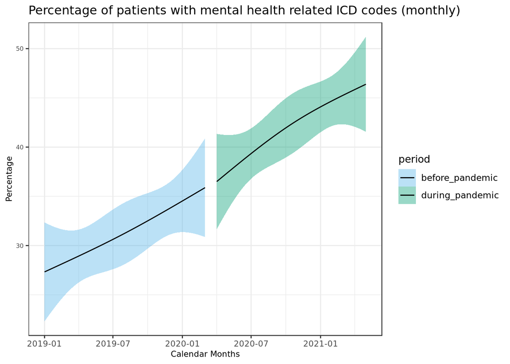

```r
#estimate the number of patients per week
patient_count_monthly %>%
  filter(icd_description_category == "Psy") %>%
  ggplot(aes(x = month, y = percentage, fill = period)) +
  #geom_line()+
  scale_fill_manual(values = cbPalette[c(3,4)]) +
  labs(y = "Percentage",
       x = "Calendar Months",
       title = "Percentage of patients with mental health related ICD codes (monthly)") +
  geom_smooth(method = "lm", formula = y ~ splines::ns(x, 2), se = TRUE, aes(colour=period), colour= "black", size = 0.5)
```

```r
ggsave("output/overall_monthly_count_all.png", width = 18, height = 9, units="cm")
```

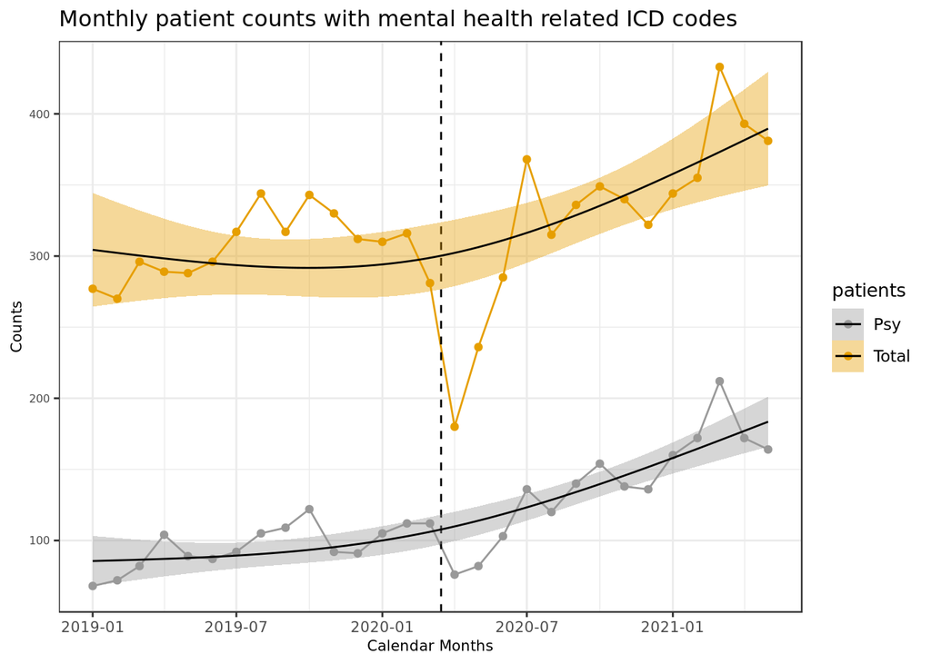

```r
patient_count_monthly %>%
  filter( icd_description_category %in% c("Psy")) %>%
  pivot_longer(names_to = "patients", cols=c(patients_per_category, total_patients)) %>%
  mutate( patients = ifelse( patients == "patients_per_category", "Psy", "Total")) %>%
  ggplot(aes(x = month, y = value, fill = patients, color = patients)) +
  geom_point() +
  geom_line() +
  geom_vline(xintercept = as.Date(pandemic_start_date),
             linetype = "dashed") +
  scale_fill_manual(values = cbPalette) +
  scale_color_manual(values = cbPalette) +
  labs(y = "Counts",
       x = "Calendar Months",
       title = "Monthly patient counts with mental health related ICD codes") +
  geom_smooth(method = "lm", formula = y ~ splines::ns(x, 2), se = TRUE, aes(colour=period), colour= "black", size = 0.5)
```

```r
ggsave("output/overall_weekly_count_all_comparison.png", width = 18, height = 9, units="cm")
```

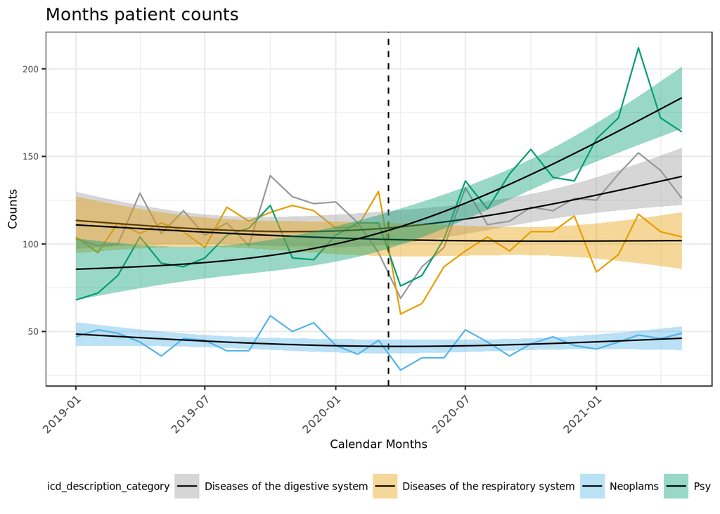

```r
patient_count_monthly %>%
  filter( icd_description_category %in% c("Psy","Neoplams","Diseases of the respiratory system","Diseases of the digestive system")) %>%
  ggplot(aes(x = month, y = patients_per_category, fill = icd_description_category, color = icd_description_category)) +
  #geom_point(alpha=0.2) +
  geom_line() +
  geom_vline(xintercept = as.Date(pandemic_start_date),
             linetype = "dashed") +
  scale_fill_manual(values = cbPalette) +
  scale_color_manual(values = cbPalette) +
  labs(y = "Counts",
       x = "Calendar Months",
       title = "Months patient counts") +
  theme(axis.text.x = element_text(angle=45, vjust = 1, hjust=1), legend.position = "bottom", legend.text = element_text(size=7), legend.title = element_text(size=7) ) +
  geom_smooth(method = "lm", formula = y ~ splines::ns(x, 2), se = TRUE, aes(colour=period), colour= "black", size = 0.5)
```

```r
ggsave("output/overall_monthly_count_all_comparison_other_categories.png", width = 18, height = 9, units="cm")
```

## Interrupted Time-Serie Analysis

```r
#
patient_count_monthly_psy <- patient_count_monthly %>%
  filter(icd_description_category == "Psy",
         !month %in% c(as.Date("2019-01-01"), as.Date("2019-02-01")) & month != max(month)) %>%
  mutate(time = seq_along(month),
         month_year = format(month, "%m"))
```

```r
# Model without seasonality
time_serie_analysis_plotting <- function(model, patient_count_monthly_psy) {
  summary(model)
  output_model <- broom::tidy(model)
  coeff_slope <- round(output_model[output_model$term == "periodduring_pandemic:time", "estimate"][[1]], 3)
  pvalue_slope <- round(output_model[output_model$term == "periodduring_pandemic:time", "p.value"][[1]], 3)
  annotation <- paste0("Lockdown slope: ", coeff_slope, " (pvalue: ", pvalue_slope, ")")
  pred_model <- predict(model, patient_count_monthly_psy, type = "response", interval = "confidence") %>% as.data.frame()
  pred_model_b <- predict(model, mutate(patient_count_monthly_psy, period = "before_pandemic"), type = "response", interval = "confidence") %>%
    as.data.frame()
  names(pred_model_b) <- paste0(names(pred_model_b), "_wo_intervention")

  pred_model <- bind_cols(patient_count_monthly_psy, pred_model, pred_model_b)
  plot <- ggplot(pred_model, aes(x = month, y = percentage)) +
    geom_point() +
    geom_line(aes(x = month, y = fit, colour = "Mean pandemic")) +
    geom_line(aes(x = month, y = fit_wo_intervention, colour = "Expected mean w/o pandemic"), linetype = "dashed") +
    scale_color_manual(name = "Time Series projection", values = c("Mean pandemic" = "black", "Expected mean w/o pandemic" = "red")) +
    geom_ribbon(aes(ymin = lwr, ymax = upr), alpha = 0.3) +
    # geom_ribbon(aes(ymin = lwr, ymax = upr), alpha = 0.3) +
    geom_vline(xintercept = as.Date(pandemic_start_date), linetype = "dashed") +
    annotate("text", x = as.Date("2019-10-01"), y = max(pred_model$percentage) + 5, label = annotation) +
    theme(legend.position = "bottom")
  return(plot)
}
```

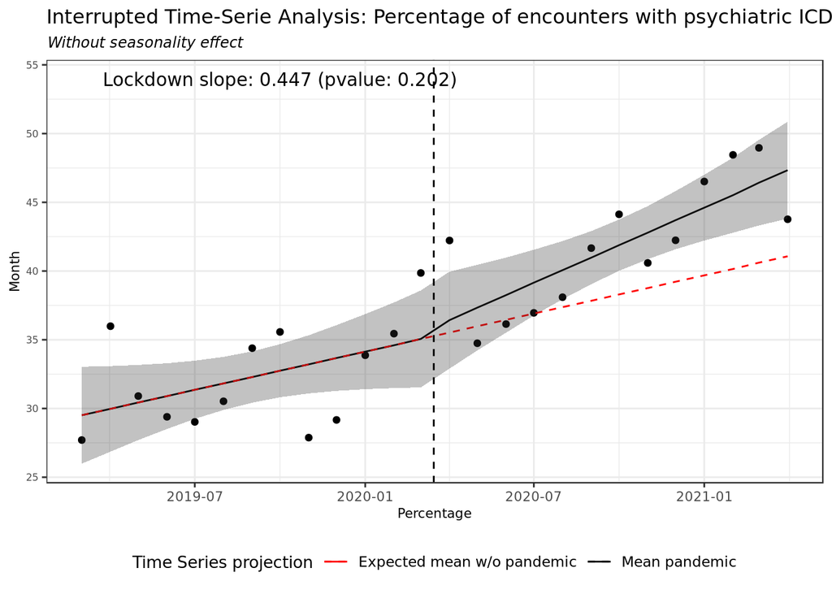

```r
# Time series analysis of percentage of psy codes per encounter, linear (without seasonality)
ts_linear_percent <- lm(percentage ~ period * time, patient_count_monthly_psy)
time_serie_analysis_plotting(ts_linear_percent, patient_count_monthly_psy) +
    labs(title = "Interrupted Time-Serie Analysis: Percentage of encounters with psychiatric ICD codes",
         subtitle = "Without seasonality effect",
         x = "Percentage",
         y = "Month")
```

```r
ggsave("output/time_series_percent_linear.png", width = 18, height = 9, units="cm")
```

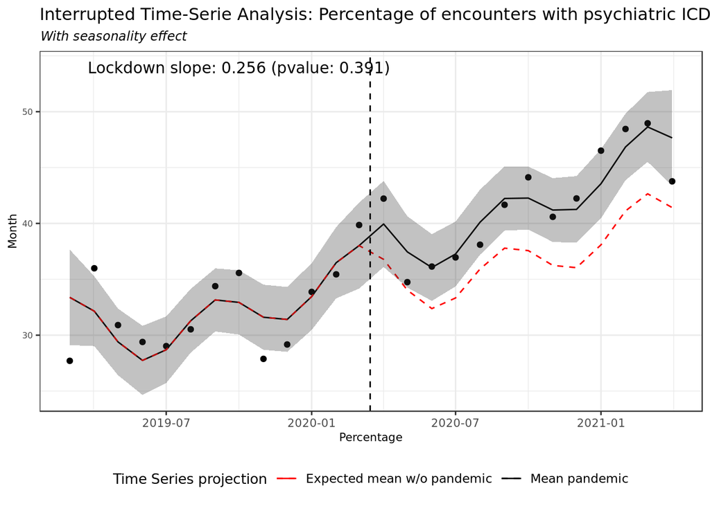

```r
# Time series analysis of percentage of psy codes per encounter, with seasonality
ts_seasonal_percent <- lm(percentage ~ period*time + harmonic(month_year, 2, 12), patient_count_monthly_psy)
time_serie_analysis_plotting(ts_seasonal_percent, patient_count_monthly_psy) +
  labs(title = "Interrupted Time-Serie Analysis: Percentage of encounters with psychiatric ICD codes",
       subtitle = "With seasonality effect",
       x = "Percentage",
       y = "Month")
```

```r
ggsave("output/time_series_percent_seasonal.png", width = 18, height = 9, units="cm")
```

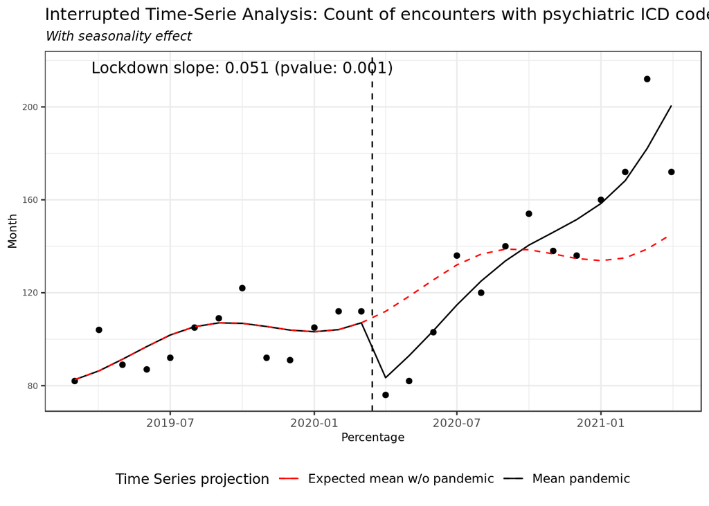

```r
# Time series analysis of percentage of icd code count, with seasonality
ts_count_seasonal <- glm(patients_per_category ~ period*time + harmonic(month_year, 1, 12),
                       family = quasipoisson,
                       patient_count_monthly_psy)

output_ts_seasonal_count <- broom::tidy(ts_count_seasonal)
coeff_slope <- round(output_ts_seasonal_count[output_ts_seasonal_count$term == "periodduring_pandemic:time", "estimate"][[1]], 3)
pvalue_slope <- round(output_ts_seasonal_count[output_ts_seasonal_count$term == "periodduring_pandemic:time", "p.value"][[1]], 3)
annotation <- paste0("Lockdown slope: ", coeff_slope, " (pvalue: ", pvalue_slope, ")")
pred_ts_seasonal_count <- predict(ts_count_seasonal, patient_count_monthly_psy, type = "response") %>% data.frame(fit = .)
pred_ts_seasonal_count_b <- predict(ts_count_seasonal, mutate(patient_count_monthly_psy, period = "before_pandemic"), type = "response")%>% data.frame(fit = .)
names(pred_ts_seasonal_count_b) <- paste0(names(pred_ts_seasonal_count_b), "_wo_intervention")

pred_ts_seasonal_count <- bind_cols(patient_count_monthly_psy, pred_ts_seasonal_count, pred_ts_seasonal_count_b)
ggplot(pred_ts_seasonal_count, aes(x = month, y = patients_per_category)) +
  geom_point() +
  geom_line(aes(x = month, y = fit, colour = "Mean pandemic")) +
  geom_line(aes(x = month, y = fit_wo_intervention, colour = "Expected mean w/o pandemic"), linetype = "dashed") +
  scale_color_manual(name = "Time Series projection", values = c("Mean pandemic" = "black", "Expected mean w/o pandemic" = "red")) +
  geom_vline(xintercept = as.Date(pandemic_start_date), linetype = "dashed") +
  annotate("text", x = as.Date("2019-10-01"), y = max(pred_ts_seasonal_count$patients_per_category) + 5, label = annotation) +
  labs(title = "Interrupted Time-Serie Analysis: Count of encounters with psychiatric ICD codes",
       subtitle = "With seasonality effect",
       x = "Percentage",
       y = "Month") +
  theme(legend.position = "bottom")
```

```r
ggsave("output/time_series_count_seasonal.png", width = 18, height = 9, units="cm")
```

## Temporal trend of hospitalized patients per day

```r
# Creating encounter table with observation assigned to encounters
# 1. Creating encounters identifiers based on clinical_raw information about start and end date of an encounter --> n_hospitalisation
# 2. Assigning ICD codes to encounters (because they are assigned to the first or last day but usually are meaningful for the entire encounter)
encounters_obs <- clinical_raw %>%
  filter(in_hospital == 1) %>%
  select(patient_num, cohort, days_since_admission, n_hospitalisation) %>%
  left_join(obs_raw[obs_raw$concept_type == "DIAG-ICD10",], on = c("patient_num", "cohort", "days_since_admission")) %>%
  drop_na(concept_type) %>%
  distinct(patient_num, cohort, n_hospitalisation, concept_type, concept_code)
obs_by_day <- encounters_obs %>%
  filter(concept_code %in% icdCodes$ICD10_Code) %>%
  left_join(clinical_raw[clinical_raw$in_hospital == 1, c("patient_num", "cohort", "n_hospitalisation", "calendar_date")],
            on = c("patient_num", "n_hospitalisation")) %>%
  group_by(calendar_date) %>%
  summarise(patient_count = n_distinct(patient_num, cohort)) %>%
  mutate(calendar_date = as.Date(calendar_date, format=dateFormat),
         period = if_else(calendar_date < pandemic_start_date,
                          "Before the Start of the Pandemic",
                          "After the Start of the Pandemic"
         ),
         patient_count = ifelse(patient_count > obfuscation | isFALSE(obfuscation),
                                 patient_count,
                                 0.5)
  )
```

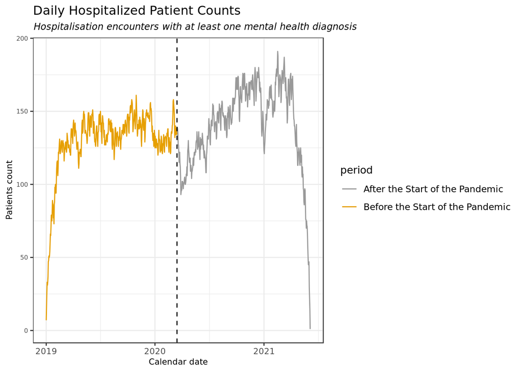

```r
ggplot(obs_by_day, aes(x = calendar_date,
                       y = patient_count,
                       color = period))  +
  geom_line() +
  geom_vline(xintercept = as.Date(pandemic_start_date),
             linetype = "dashed") +
  #geom_vline(xintercept = as.Date(late_pandemic_start_date),
  #           linetype = "dashed") +
  scale_color_manual(values = cbPalette) +
  labs(x = "Calendar date",
       y = "Patients count",
       title = "Daily Hospitalized Patient Counts",
       subtitle = "Hospitalisation encounters with at least one mental health diagnosis",
       legend = "Period")
```

```r
ggsave("output/hospitalized_patients_all.png", width = 18, height = 9, units="cm")
```

### Patients count per week aggregated by sex

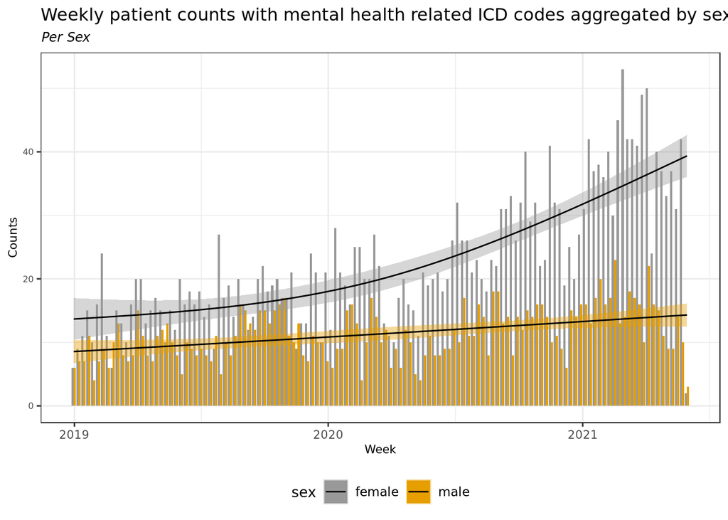

```r
patient_count_per_week_sex <- input_data[, c("patient_num", "cohort", "sex","weeks")] %>%
  unique() %>%
  group_by(weeks, sex) %>%
  tally() %>%
  mutate(n = ifelse( n > obfuscation | isFALSE(obfuscation),
                     n,
                     0.5),
         siteid = site)

patient_count_per_week_sex %>%
  ggplot(aes(x = as.Date(weeks), y = n, fill = sex)) +
  geom_bar(stat="identity", position = "dodge")+
  scale_fill_manual(values = cbPalette) +
  labs(y = "Counts",
       x = "Week",
       title = "Weekly patient counts with mental health related ICD codes aggregated by sex",
       subtitle = "Per Sex") +
  theme(legend.position = "bottom") +
  geom_smooth(method = "lm", formula = y ~ splines::ns(x, 2), se = TRUE, aes(colour=sex), colour= "black", size = 0.5)
```

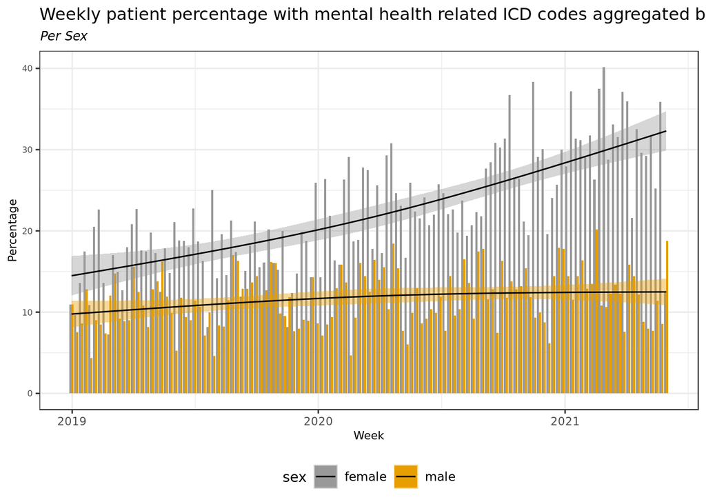

```r
ggsave("output/overall_weekly_count_all.png", width = 18, height = 9, units="cm")

###percentage
patient_count_per_week_sex <- merge( patient_count_per_week_sex, patient_count_per_week )

patient_count_per_week_sex %>%
  mutate(percentage = n * 100 / total_patients ) %>%
  ggplot(aes(x = as.Date(weeks), y = percentage, fill = sex)) +
  geom_bar(stat="identity", position = "dodge")+
  scale_fill_manual(values = cbPalette) +
  labs(y = "Percentage",
       x = "Week",
       title = "Weekly patient percentage with mental health related ICD codes aggregated by sex",
       subtitle = "Per Sex") +
  theme(legend.position = "bottom") +
  geom_smooth(method = "lm", formula = y ~ splines::ns(x, 2), se = TRUE, aes(colour=sex), colour= "black", size = 0.5)
```

```r
ggsave("output/overall_weekly_count_all.png", width = 18, height = 9, units="cm")
```

### Patients count per week aggregated by age group

This graphic will only make sense if we include a wide range of age.

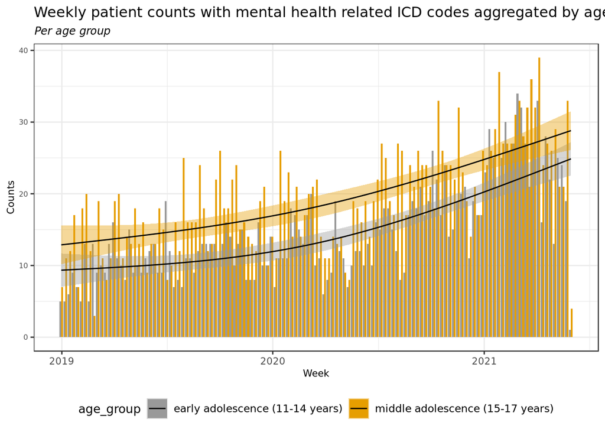

```r
#estimate the number of patients per week by age group
input_data[, c("patient_num", "cohort", "age","weeks")] %>%
  unique() %>%
  mutate( age_group = ifelse( age < 15, "early adolescence (11-14 years)", "middle adolescence (15-17 years)")) %>%
  group_by(weeks, age_group) %>%
  tally() %>%
  mutate(n = ifelse( n > obfuscation, n, obfuscation * 0.5))  %>%
    ggplot(aes(x = as.Date(weeks), y = n, fill = age_group)) +
    geom_bar(stat="identity", position = "dodge")+
    labs(y = "Counts",
         x = "Week",
         title = "Weekly patient counts with mental health related ICD codes aggregated by age group",
         subtitle = "Per age group") +
    theme(legend.position = "bottom") +
  scale_fill_manual(values = cbPalette) +
    geom_smooth(method = "lm", formula = y ~ splines::ns(x, 2), se = TRUE, aes(colour=sex), colour= "black", size = 0.5)
```

```r
ggsave("output/overall_weekly_count_age.png", width = 18, height = 9, units="cm")
```

## Patients counts per week grouping by ICD subgroup category

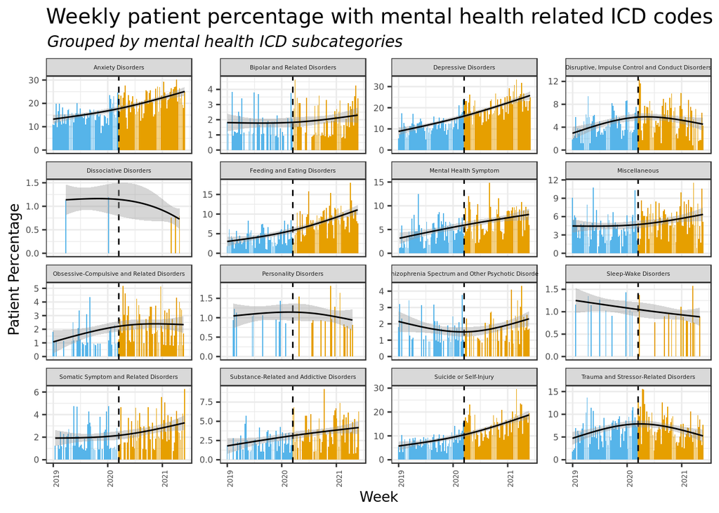

```r
patient_count_per_week_disorder_group <- input_data[, c("patient_num", "cohort", "weeks", "disorder_group")] %>%
  unique() %>%
  group_by(weeks, disorder_group) %>% tally( name = "psychiatric_patient_count") %>%
  mutate(psychiatric_patient_count = ifelse( psychiatric_patient_count > obfuscation | isFALSE(obfuscation), psychiatric_patient_count, 0.5), siteid = site)

patient_count_per_week_disorder_group <- merge( patient_count_per_week_disorder_group, patient_count_per_week)

patient_count_per_week_disorder_group %>%
  mutate(weeks = as.Date(weeks),
         period = if_else(weeks < pandemic_start_date,
                          "Before the Start of the Pandemic",
                          "After the Start of the Pandemic"
         ),
         percentage = psychiatric_patient_count * 100 / total_patients
  ) %>%
  ggplot(aes(x = as.Date(weeks), y= percentage, fill = period, group = disorder_group )) +
  geom_bar(stat = "identity")+
  geom_vline(xintercept = as.Date(pandemic_start_date),
             linetype = "dashed") +
  #geom_vline(xintercept = as.Date(late_pandemic_start_date),
  #           linetype = "dashed") +
  geom_smooth(method = "lm", formula = y ~ splines::ns(x, 2), se= TRUE, aes(colour=period), colour= "black", size = 0.5) +
  labs(x = "Week",
       y = "Patient Percentage",
       title = "Weekly patient percentage with mental health related ICD codes",
       subtitle = "Grouped by mental health ICD subcategories") +
  ylim(0, NA) +
  facet_wrap(. ~ disorder_group, scales = "free_y") +
  theme(strip.text.x = element_text(size = 4),
        axis.text.x = element_text(size = 5, angle = 90),
        axis.text.y = element_text(size = 6),
        axis.title.x = element_text(size = 10),
        axis.title.y = element_text(size = 10),
        title = element_text(size = 12),
        plot.subtitle = element_text(size = 11),
        legend.position = "none") +
  scale_fill_manual(values = cbPalette[-1])
```

```r
ggsave("output/categorical_counts_inpatient_teens_all.png", width = 18, height = 9, units="cm")
```

# Summary table 1

```r
t.test2 <- function(m1, m2, s1, s2, n1, n2) {
  # t.test computed from sample statistics, ie using mean, standard deviation and count value of the samples
  # useful in case we can only retrieve aggregated stats from the sites
  # ref: https://stats.stackexchange.com/questions/30394/how-to-perform-two-sample-t-tests-in-r-by-inputting-sample-statistics-rather-tha
  # and https://en.wikipedia.org/wiki/Student%27s_t-test?oldformat=true#Equal_or_unequal_sample_sizes,_unequal_variances_(sX1_%3E_2sX2_or_sX2_%3E_2sX1)
  se <- sqrt( (s1^2/n1) + (s2^2/n2) )
  # welch-satterthwaite df
  df <- ( (s1^2/n1 + s2^2/n2)^2 )/( (s1^2/n1)^2/(n1-1) + (s2^2/n2)^2/(n2-1) )
  t <- (m1-m2)/se
  dat <- c(m1-m2, se, t, 2*pt(-abs(t),df))
  names(dat) <- c("Difference of means", "Std Error", "t", "p-value")
  return(dat)
}
```

## Age

```r
age_stats <- input_data %>%
  dplyr::distinct(patient_num, cohort, period, age) %>%
  filter(age != 0) %>%
  dplyr::group_by( period ) %>%
  dplyr::summarise( mean = mean( age ),
                    sd = sd( age ),
                    count = n()) %>%
  dplyr::mutate(count = ifelse( count > obfuscation, count, obfuscation * 0.5)) %>%
  dplyr::ungroup() %>%
  dplyr::bind_rows(
    dplyr::summarise(input_data, period="Total", mean=mean(age), sd=sd(age), count = n())
  )

age_test <- t.test2(m1 = age_stats[[1, "mean"]],
                    m2 = age_stats[[2, "mean"]],
                    s1 = age_stats[[1, "sd"]],
                    s2 = age_stats[[2, "sd"]],
                    n1 = age_stats[[1, "count"]],
                    n2 = age_stats[[2, "count"]]) %>%
  `[[`("p-value")
```

## Sex

```r
sex <- input_data %>%
  dplyr::group_by( sex ) %>%
  dplyr::summarise( count = n_distinct(patient_num, cohort) ) %>%
  dplyr::mutate( count = ifelse( count > obfuscation, count, obfuscation * 0.5),
                 total = sum( count ), percentage = round( count/total*100, 2)  )

sex_by_period <- input_data %>%
  group_by(period, sex ) %>%
  summarise(count = n_distinct(patient_num, cohort)) %>%
  group_by(period, .add=TRUE) %>%
  mutate( count = ifelse( count > obfuscation, count, obfuscation * 0.5),
          percentage=round(count/sum( count )*100, 2)) %>%
  replace_na(list(male = 0, female = 0))
sex_test <- sex_by_period %>%
  select(-percentage) %>%
  pivot_wider(names_from = sex, values_from = count) %>%
  ungroup() %>%
  select(male, female) %>%
  chisq.test() %>%
  `[[`("p.value")
```

## Race

```r
if( raceAvailable == TRUE ){
  race <- input_data %>%
    dplyr::group_by( race_4ce ) %>%
    dplyr::summarise( count = n_distinct(patient_num, cohort) ) %>%
    dplyr::mutate( count = ifelse( count > obfuscation, count, obfuscation * 0.5),
                   total = sum( count ), percentage = round( count/total*100, 2)  )

  race_by_period <- input_data %>%
    group_by(period, race_4ce ) %>%
    summarise(count = n_distinct(patient_num, cohort)) %>%
    group_by(period, .add=TRUE) %>%
    mutate( count = ifelse( count > obfuscation, count, obfuscation * 0.5),
            percentage=round(count/sum( count )*100, 2))


summary_race_test <- race_by_period %>%
  select(-percentage) %>%
  tidyr::pivot_wider(names_from = period,
                     values_from = count) %>%
  select(during_pandemic) %>%
  tidyr::replace_na(list(during_pandemic = 0)) %>%
  chisq.test() %>%
  `[[`("p.value")
}
```

## Diagnosis

### By ICD code

```r
summary_diagnosis <- input_data %>%
  dplyr::distinct( patient_num, cohort, description, period, weeks, concept_code ) %>%
  dplyr::group_by( concept_code, description, period ) %>%
  dplyr::count( patient_num, cohort ) %>%
  dplyr::tally(name = "count") %>%
  dplyr::mutate(count = ifelse( count > obfuscation, count, obfuscation * 0.5)) %>%
  dplyr::arrange( desc(count) ) %>%
  dplyr::ungroup()

summary_diagnosis_test <- summary_diagnosis %>%
  tidyr::pivot_wider(names_from = period,
                     values_from = count) %>%
  #select(late_pandemic, early_pandemic) %>%
  select(during_pandemic) %>%
  #tidyr::replace_na(list(late_pandemic = 0, early_pandemic = 0)) %>%
  tidyr::replace_na(list(during_pandemic = 0)) %>%
  chisq.test() %>%
  `[[`("p.value")
```

### By disorder group

```r
summary_disorder_group <- input_data %>%
  dplyr::group_by( disorder_group ) %>%
  dplyr::count( patient_num, cohort ) %>%
  dplyr::tally(name = "count") %>%
  dplyr::mutate(count = ifelse( count > obfuscation, count, obfuscation * 0.5)) %>%
  dplyr::arrange( desc( count ))

summary_disorder_group_by_period <- input_data %>%
  dplyr::distinct( patient_num, disorder_group, period, weeks ) %>%
  dplyr::group_by( period, disorder_group ) %>%
  summarise(count = n_distinct(patient_num)) %>%
  group_by(period, add=TRUE) %>%
  mutate(count = ifelse( count > obfuscation, count, obfuscation * 0.5),
         percentage=round(count/sum( count )*100, 2))
summary_disorder_group_by_period_test <- summary_disorder_group_by_period %>%
  pivot_wider(id_cols = disorder_group, names_from = period, values_from = c(count, percentage)) %>%
  mutate(across(where(is.numeric), ~replace_na(.x, replace = 0))) %>%
  #select(count_early_pandemic, count_late_pandemic) %>%
  select(count_during_pandemic) %>%
  chisq.test() %>%
  `[[`("p.value")
```

## Hospitalization

### Length of hospitalization

```r
## Calculating also mean and sd in case we can only retrieve aggregated data from the sites
hospit_length <- input_data %>%
  dplyr::distinct( patient_num, cohort, n_hospitalisation, len_hospitalisation, period ) %>%
  dplyr::group_by( period ) %>%
  dplyr::summarise( n_hospitalisations = n(),
                    length_hospt_median = median(len_hospitalisation),
                    IQR = IQR( len_hospitalisation),
                    length_hospt_mean = round(mean(len_hospitalisation), 2),
                    length_hospt_sd = round(sd(len_hospitalisation), 2))



hospit_length_mean_test <- t.test2(
  m1 = hospit_length[[1, "length_hospt_mean"]],
  m2 = hospit_length[[2, "length_hospt_mean"]],
  s1 = hospit_length[[1, "length_hospt_sd"]],
  s2 = hospit_length[[2, "length_hospt_sd"]],
  n1 = hospit_length[[1, "n_hospitalisations"]],
  n2 = hospit_length[[2, "n_hospitalisations"]]
)
```

### Repeat hospitalizations by patient

```r
hospitalisation_count <- input_data %>%
  dplyr::distinct( patient_num, cohort, period, n_hospitalisation ) %>%
  dplyr::group_by( period, patient_num, cohort ) %>%
  dplyr::filter(n_hospitalisation == max(n_hospitalisation)) %>%
  dplyr::group_by( period, add = FALSE) %>%
  dplyr::summarise( mean_count_hospitalizations = mean(n_hospitalisation),
                    max_count_hospitalizations = max(n_hospitalisation),
                    median_count_hospitalizations = median(n_hospitalisation),
                    sd_hospitalisation_count = sd(n_hospitalisation),
                    IQR_hospitalisation_count = IQR( n_hospitalisation ))

repeated_hospitalisation <- input_data %>%
  dplyr::distinct( patient_num, cohort, period, n_hospitalisation ) %>%
  dplyr::group_by(patient_num, cohort, period) %>%
  dplyr::filter(n_hospitalisation == max(n_hospitalisation)) %>%
  dplyr::mutate(repeated_hospitalisation = if_else(n_hospitalisation > 1, "repeated", "non_repeated")) %>%
  dplyr::group_by( period, add = FALSE ) %>%
  dplyr::count( repeated_hospitalisation ) %>%
  tidyr::pivot_wider(names_from = repeated_hospitalisation, values_from = n) %>%
  replace_na(list("non_repeated" = 0, "repeated" = 0))
repeated_hospitalisation_test <- chisq.test(repeated_hospitalisation[, c("non_repeated", "repeated")]) %>%
  `[[`("p.value")
```

## Pulling together Table 1 statistics

```r
format_counts <- function(count, percentage) {
  glue::glue("{count} ({percentage} %)", count = count, percentage = percentage)
}

sex_table1 <- sex_by_period %>%
  bind_rows(
    sex_by_period %>%
      group_by(period) %>%
      dplyr::summarise(sex = "Total", count = sum(count), percentage = sum(percentage))
  ) %>%
  mutate(result = format_counts(count, percentage)) %>%
  select(-c(count, percentage)) %>%
  pivot_wider( names_from = period, values_from = result ) %>%
  rename(name = sex)

if( raceAvailable == TRUE ){
  race_table1 <- race_by_period %>%
  bind_rows(
    race_by_period %>%
      group_by(period) %>%
      dplyr::summarise(race_4ce = "Total", count = sum(count), percentage = sum(percentage))
  ) %>%
  mutate(result = format_counts(count, percentage)) %>%
  select(-c(count, percentage)) %>%
  pivot_wider( names_from = period, values_from = result ) %>%
  rename(name = race_4ce)
}

diagnosis_table1 <- summary_diagnosis %>%
    bind_rows(
    sex_by_period %>%
      group_by(period) %>%
      dplyr::summarise(concept_code = "Total", count = sum(count))
  ) %>%
  pivot_wider( names_from = period, values_from = count) %>%
  mutate(diag = paste(concept_code, description, sep = ": ")) %>%
  select(diag, before_pandemic, during_pandemic) %>%
  rename(name = diag)

disorder_table1 <- summary_disorder_group_by_period %>%
  bind_rows(
    dplyr::summarise(., disorder_group="Total", across(where(is.numeric), sum))
  ) %>%
  mutate(result = format_counts(count, percentage)) %>%
  select(-c(count, percentage)) %>%
  pivot_wider( names_from = period, values_from = result ) %>%
  replace_na( list(during_pandemic = "0 (0 %)")) %>%
  rename(name = disorder_group)


hospit_table1 <- hospit_length %>%
  mutate(median = glue::glue("{median} ({IQR})", median = length_hospt_median, IQR = IQR),
         mean = glue::glue("{mean} ({sd})", mean = length_hospt_mean, sd = length_hospt_sd),
         n_hospitalisations = as.character(n_hospitalisations)) %>%
  select(median, mean, n_hospitalisations, period) %>%
  pivot_longer(cols = c("n_hospitalisations", "median", "mean")) %>%
  pivot_wider(names_from = period, values_from = value)

repeated_hospit_table1 <- repeated_hospitalisation %>%
  pivot_longer(cols = c("non_repeated", "repeated")) %>%
  pivot_wider(names_from = period, values_from = value)

list_tests <- c("Sex" = sex_test,
             "Hospitalisations length" = repeated_hospitalisation_test,
             "Repeated hospitalisations" = repeated_hospitalisation_test,
             "Diagnoses" = summary_diagnosis_test,
             "Disorder groups" = summary_disorder_group_by_period_test)

list_table1 <- list(
    "Sex" = sex_table1,
    "Hospitalisations length" = hospit_table1,
    "Repeated hospitalisations" = repeated_hospit_table1,
    "Disorder groups" = disorder_table1,
    "Diagnoses" = diagnosis_table1)
if (raceAvailable) {
  list_tests["Race"] = summary_race_test
  list_table1 = c(list("Race" = race_table1),
          list_table1
  )
}


tests <- list_tests %>%
  data.frame() %>%
  round(2)
names(tests) <- "pvalue"
tests["Category"] <- row.names(tests)

table1 <- list_table1 %>%
  lapply(function(df) mutate(df, across(.fns = as.character))) %>%
  dplyr::bind_rows(.id = "Category") %>%
  dplyr::left_join(tests, by = "Category")


table1 %>%
  group_by(Category) %>%
  mutate(pvalue = ifelse(duplicated(pvalue, fromLast = TRUE), "", as.character(pvalue))) %>%
  ungroup() %>%
  mutate(Category = "") %>%
  mutate(across(.cols = c(before_pandemic, during_pandemic), .fns = replace_na, "0")) %>%
  rename_with(str_to_title) %>%
  rename_with(sub, pattern = "_", replacement = " ") %>%
  mutate(across(.fns = str_to_title)) %>%
  mutate(across(.fns = sub, pattern = "_", replacement = " ")) %>%
  kable( booktabs = T) %>%
  kableExtra::kable_styling(latex_options = "striped") %>%
  kableExtra::group_rows(index = setNames(rle(table1$Category)[[1]], rle(table1$Category)[[2]]))
```

| Category | Name | Before pandemic | During pandemic | Pvalue |
| --- | --- | --- | --- | --- |
| **Race** |  |  |  |  |
|  | American indian | 3 (0.29 %) | 1 (0.07 %) |  |
|  | Asian | 31 (3.02 %) | 47 (3.47 %) |  |
|  | Black | 92 (8.95 %) | 111 (8.2 %) |  |
|  | No information | 126 (12.26 %) | 151 (11.16 %) |  |
|  | Other | 143 (13.91 %) | 184 (13.6 %) |  |
|  | White | 631 (61.38 %) | 858 (63.41 %) |  |
|  | NA | 2 (0.19 %) | 1 (0.07 %) |  |
|  | Total | 1028 (100 %) | 1353 (99.98 %) | 0 |
| **Sex** |  |  |  |  |
|  | Female | 628 (61.09 %) | 906 (66.96 %) |  |
|  | Male | 400 (38.91 %) | 447 (33.04 %) |  |
|  | Total | 1028 (100 %) | 1353 (100 %) | 0 |
| **Hospitalisations length** |  |  |  |  |
|  | N hospitalisations | 1287 | 1768 |  |
|  | Median | 8 (11) | 8 (12) |  |
|  | Mean | 13.85 (19.71) | 14.43 (19.95) | 0 |
| **Repeated hospitalisations** |  |  |  |  |
|  | Non repeated | 767 | 919 |  |
|  | Repeated | 261 | 434 | 0 |
| **Disorder groups** |  |  |  |  |
|  | Anxiety Disorders | 614 (23.35 %) | 886 (22.09 %) |  |
|  | Bipolar And Related Disorders | 45 (1.71 %) | 56 (1.4 %) |  |
|  | Depressive Disorders | 461 (17.53 %) | 766 (19.1 %) |  |
|  | Disruptive, Impulse Control And Conduct Disorders | 157 (5.97 %) | 184 (4.59 %) |  |
|  | Dissociative Disorders | 2 (0.08 %) | 1 (0.02 %) |  |
|  | Feeding And Eating Disorders | 139 (5.29 %) | 283 (7.06 %) |  |
|  | Mental Health Symptom | 205 (7.79 %) | 302 (7.53 %) |  |
|  | Miscellaneous | 213 (8.1 %) | 287 (7.16 %) |  |
|  | Obsessive-Compulsive And Related Disorders | 34 (1.29 %) | 94 (2.34 %) |  |

[output cut: 411 more lines]

# Save the output in a RData file.

```r
length_hospitalisation_values <- input_data %>%
  dplyr::distinct( patient_num, n_hospitalisation, len_hospitalisation ) %>%
  dplyr::mutate( siteid = site ) %>%
  dplyr::select( len_hospitalisation, siteid )


save( patient_count_barplot_period,
      patient_count_per_week,
      patient_count_per_week_sex,
      patient_count_per_week_disorder_group,
      table1,
      length_hospitalisation_values,
      obs_by_day,
      file = paste0("output/peds_psy_aggResults_", unique(as.character(demo_raw$siteid)), ".RData"))
```